# Data Analysis and Plotting in Python with Pandas

*Adel Dabah, Jülich Supercomputing Centre, Forschungszentrum Jülich, 30 March 2026*

*MATSE Version*

## My Motivation

- I like Python
- I like plotting data
- I like sharing
- I think Pandas is awesome and you should use it too
- …*but I'm no Python expert!*

*Motto: **»Pandas as early as possible!«***

## Task Outline

- Task 1
- Task 2
- Task 3
- Task 4
- Task 5
- Task 6
- Task 7
- Task 7B
- Task 8
- Task 8B

## Course Setup

- Originally, a 3 h course (incleaing break)
- This is the two-day MATSE lecture, with plenty of space and some new material
- Alternating between lecture and hands-on
- Please now open Jupyter Notebook of this session from Sciebo

## About Pandas

[figure not shown]

- Python package (Python 3)
- For data analysis and manipulation
- With data structures (multi-dimensional table; time series), operations
- Name from »**Pan**el **Da**ta« (multi-dimensional time series in economics)
- Since 2008
- https://pandas.pydata.org/
- Install [via PyPI](https://pypi.org/project/pandas/): `pip install pandas`
- *Cheatsheet: https://pandas.pydata.org/Pandas_Cheat_Sheet.pdf*

## Pandas Cohabitation

- Pandas works great together with other established Python tools
  - [Jupyter Notebooks](https://jupyter.org/)
  - Plotting with [`matplotlib`](https://matplotlib.org/)
  - Numerical analysis with [`numpy`](https://numpy.org/)
  - Modelling with [`statsmodels`](https://www.statsmodels.org/stable/index.html), [`scikit-learn`](https://scikit-learn.org/)
  - Nicer plots with [`seaborn`](https://seaborn.pydata.org/), [`altair`](https://altair-viz.github.io/), [`plotly`](https://plot.ly/)
  - Performance enhancement with [Cython](https://cython.org/), Numba, …
- Tools building up on Pandas: [cuDF](https://github.com/rapidsai/cudf) (GPU-accelerated DataFrames in [Rapids](https://rapids.ai/)), [pyarrow](https://arrow.apache.org/docs/python/index.html) (Apache Arrow bindings in Python) …

## First Steps

```python
import pandas
```

```python
import pandas as pd
```

```python
pd.__version__
```

```
'2.2.3'
```

```python
%pdoc pd
```

```
Class docstring:
    pandas - a powerful data analysis and manipulation library for Python
    =====================================================================

    **pandas** is a Python package providing fast, flexible, and expressive data
    structures designed to make working with "relational" or "labeled" data both
    easy and intuitive. It aims to be the fundamental high-level building block for
    doing practical, **real world** data analysis in Python. Additionally, it has
    the broader goal of becoming **the most powerful and flexible open source data
    analysis / manipulation tool available in any language**. It is already well on
    its way toward this goal.

    Main Features
    -------------
    Here are just a few of the things that pandas does well:

      - Easy handling of missing data in floating point as well as non-floating
        point data.
      - Size mutability: columns can be inserted and deleted from DataFrame and
        higher dimensional objects
      - Automatic and explicit data alignment: objects can be explicitly aligned
        to a set of labels, or the user can simply ignore the labels and let
        `Series`, `DataFrame`, etc. automatically align the data for you in
        computations.
      - Powerful, flexible group by functionality to perform split-apply-combine
        operations on data sets, for both aggregating and transforming data.
      - Make it easy to convert ragged, differently-indexed data in other Python
        and NumPy data structures into DataFrame objects.
      - Intelligent label-based slicing, fancy indexing, and subsetting of large
        data sets.
      - Intuitive merging and joining data sets.
      - Flexible reshaping and pivoting of data sets.
      - Hierarchical labeling of axes (possible to have multiple labels per tick).
      - Robust IO tools for loading data from flat files (CSV and delimited),
        Excel files, databases, and saving/loading data from the ultrafast HDF5
        format.
      - Time series-specific functionality: date range generation and frequency
        conversion, moving window statistics, date shifting and lagging.
```

## DataFrames

### It's all about DataFrames

[figure not shown]

- Data containers of Pandas:
  - Linear: `Series`
  - Multi Dimension: `DataFrame`
- `Series` is *only* special (1D) case of `DataFrame`
- → We use `DataFrame`s as the more general case here

## DataFrames

### Construction

- To show features of `DataFrame`, let's construct one and show by example!
- Many construction possibilities
  - From lists, dictionaries, `numpy` objects
  - From CSV, HDF5, JSON, Excel, HTML, fixed-width files
  - From pickled Pandas data
  - From clipboard
  - *From Feather, Parquet, SAS, SQL, Google BigQuery, STATA*

## DataFrames

### Examples, finally

```python
ages  = [41, 56, 56, 57, 39, 59, 43, 56, 38, 60]
```

```python
pd.DataFrame(ages)
```

|  | 0 |
| --- | --- |
| 0 | 41 |
| 1 | 56 |
| 2 | 56 |
| 3 | 57 |
| 4 | 39 |
| 5 | 59 |
| 6 | 43 |
| 7 | 56 |
| 8 | 38 |
| 9 | 60 |

```python
df_ages = pd.DataFrame(ages)
df_ages.head(3)
```

|  | 0 |
| --- | --- |
| 0 | 41 |
| 1 | 56 |
| 2 | 56 |

- Let's add names to ages; put everything into a `dict()`

```python
data = {
    "Name": ["Liu", "Rowland", "Rivers", "Waters", "Rice", "Fields", "Kerr", "Romero", "Davis", "Hall"],
    "Age": ages
}
print(data)
```

```
{'Name': ['Liu', 'Rowland', 'Rivers', 'Waters', 'Rice', 'Fields', 'Kerr', 'Romero', 'Davis', 'Hall'], 'Age': [41, 56, 56, 57, 39, 59, 43, 56, 38, 60]}
```

```python
df_sample = pd.DataFrame(data)
df_sample.head(4)
```

|  | Name | Age |
| --- | --- | --- |
| 0 | Liu | 41 |
| 1 | Rowland | 56 |
| 2 | Rivers | 56 |
| 3 | Waters | 57 |

- Automatically creates columns from dictionary
- Two columns now; one for names, one for ages

```python
df_sample.columns
```

```
Index(['Name', 'Age'], dtype='object')
```

- First column is *index*
- `DataFrame` always have indexes; auto-generated or custom

```python
df_sample.index
```

```
RangeIndex(start=0, stop=10, step=1)
```

- Make `Name` be index with `.set_index()`
- `inplace=True` will modifiy the parent frame (*I don't like it*)

```python
df_sample.set_index("Name", inplace=True)
df_sample
```

| Name | Age |
| --- | --- |
| Liu | 41 |
| Rowland | 56 |
| Rivers | 56 |
| Waters | 57 |
| Rice | 39 |
| Fields | 59 |
| Kerr | 43 |
| Romero | 56 |
| Davis | 38 |
| Hall | 60 |

- Some more operations

```python
df_sample.describe()
```

|  | Age |
| --- | --- |
| count | 10.000000 |
| mean | 50.500000 |
| std | 9.009255 |
| min | 38.000000 |
| 25% | 41.500000 |
| 50% | 56.000000 |
| 75% | 56.750000 |
| max | 60.000000 |

```python
df_sample.info()
```

```
<class 'pandas.core.frame.DataFrame'>
Index: 10 entries, Liu to Hall
Data columns (total 1 columns):
 #   Column  Non-Null Count  Dtype
---  ------  --------------  -----
 0   Age     10 non-null     int64
dtypes: int64(1)
memory usage: 160.0+ bytes
```

```python
df_sample.T
```

| Name | Liu | Rowland | Rivers | Waters | Rice | Fields | Kerr | Romero | Davis | Hall |
| --- | --- | --- | --- | --- | --- | --- | --- | --- | --- | --- |
| Age | 41 | 56 | 56 | 57 | 39 | 59 | 43 | 56 | 38 | 60 |

```python
df_sample.T.columns
```

```
Index(['Liu', 'Rowland', 'Rivers', 'Waters', 'Rice', 'Fields', 'Kerr',
       'Romero', 'Davis', 'Hall'],
      dtype='object', name='Name')
```

- Also: Arithmetic operations

```python
df_sample.multiply(2).head(3)
```

| Name | Age |
| --- | --- |
| Liu | 82 |
| Rowland | 112 |
| Rivers | 112 |

```python
df_sample.reset_index().multiply(2).head(3)
```

|  | Name | Age |
| --- | --- | --- |
| 0 | LiuLiu | 82 |
| 1 | RowlandRowland | 112 |
| 2 | RiversRivers | 112 |

```python
(df_sample / 2).head(3)
```

| Name | Age |
| --- | --- |
| Liu | 20.5 |
| Rowland | 28.0 |
| Rivers | 28.0 |

```python
(df_sample * df_sample).head(3)
```

| Name | Age |
| --- | --- |
| Liu | 1681 |
| Rowland | 3136 |
| Rivers | 3136 |

```python
def mysquare(number: float) -> float:
    return number*number

df_sample.apply(mysquare).head()
# or: df_sample.apply(lambda x: x*x).head()
```

| Name | Age |
| --- | --- |
| Liu | 1681 |
| Rowland | 3136 |
| Rivers | 3136 |
| Waters | 3249 |
| Rice | 1521 |

```python
df_sample.apply(np.square).head()
```

| Name | Age |
| --- | --- |
| Liu | 1681 |
| Rowland | 3136 |
| Rivers | 3136 |
| Waters | 3249 |
| Rice | 1521 |

Logical operations allowed as well

```python
df_sample > 40
```

| Name | Age |
| --- | --- |
| Liu | True |
| Rowland | True |
| Rivers | True |
| Waters | True |
| Rice | False |
| Fields | True |
| Kerr | True |
| Romero | True |
| Davis | False |
| Hall | True |

```python
df_sample.apply(mysquare).head() == df_sample.apply(lambda x: x*x).head()
```

| Name | Age |
| --- | --- |
| Liu | True |
| Rowland | True |
| Rivers | True |
| Waters | True |
| Rice | True |

## Task 1

TASK

- Create data frame with
  - 6 names of dinosaurs,
  - their favourite prime number,
  - and their favorite color.
- Play around with the frame
- Tell me when you're done with status icon in BigBlueButton: 👍

```python
happy_dinos = {
    "Dinosaur Name": [],
    "Favourite Prime": [],
    "Favourite Color": []
}
#df_dinos =
```

```python
happy_dinos = {
    "Dinosaur Name": ["Aegyptosaurus", "Tyrannosaurus", "Panoplosaurus", "Isisaurus", "Triceratops", "Velociraptor"],
    "Favourite Prime": ["4", "8", "15", "16", "23", "42"],
    "Favourite Color": ["blue", "white", "blue", "purple", "violet", "gray"]
}
df_dinos = pd.DataFrame(happy_dinos).set_index("Dinosaur Name")
df_dinos.T
```

| Dinosaur Name | Aegyptosaurus | Tyrannosaurus | Panoplosaurus | Isisaurus | Triceratops | Velociraptor |
| --- | --- | --- | --- | --- | --- | --- |
| Favourite Prime | 4 | 8 | 15 | 16 | 23 | 42 |
| Favourite Color | blue | white | blue | purple | violet | gray |

### More `DataFrame` examples

```python
df_demo = pd.DataFrame({
    "A": 1.2,
    "B": pd.Timestamp('20180226'),
    "C": [(-1)**i * np.sqrt(i) + np.e * (-1)**(i-1) for i in range(5)],
    "D": pd.Categorical(["This", "column", "has", "entries", "entries"]),
    "E": "Same"
})
df_demo
```

|  | A | B | C | D | E |
| --- | --- | --- | --- | --- | --- |
| 0 | 1.2 | 2018-02-26 | -2.718282 | This | Same |
| 1 | 1.2 | 2018-02-26 | 1.718282 | column | Same |
| 2 | 1.2 | 2018-02-26 | -1.304068 | has | Same |
| 3 | 1.2 | 2018-02-26 | 0.986231 | entries | Same |
| 4 | 1.2 | 2018-02-26 | -0.718282 | entries | Same |

```python
df_demo.sort_values("C")
```

|  | A | B | C | D | E |
| --- | --- | --- | --- | --- | --- |
| 0 | 1.2 | 2018-02-26 | -2.718282 | This | Same |
| 2 | 1.2 | 2018-02-26 | -1.304068 | has | Same |
| 4 | 1.2 | 2018-02-26 | -0.718282 | entries | Same |
| 3 | 1.2 | 2018-02-26 | 0.986231 | entries | Same |
| 1 | 1.2 | 2018-02-26 | 1.718282 | column | Same |

```python
df_demo.round(2).tail(2)
```

|  | A | B | C | D | E |
| --- | --- | --- | --- | --- | --- |
| 3 | 1.2 | 2018-02-26 | 0.99 | entries | Same |
| 4 | 1.2 | 2018-02-26 | -0.72 | entries | Same |

```python
#df_demo.round(2).sum()
df_demo.round(2).sum(numeric_only=True)
```

```
A    6.00
C   -2.03
dtype: float64
```

```python
print(df_demo.round(2).to_latex())
```

```
\begin{tabular}{lrlrll}
\toprule
 & A & B & C & D & E \\
\midrule
0 & 1.200000 & 2018-02-26 00:00:00 & -2.720000 & This & Same \\
1 & 1.200000 & 2018-02-26 00:00:00 & 1.720000 & column & Same \\
2 & 1.200000 & 2018-02-26 00:00:00 & -1.300000 & has & Same \\
3 & 1.200000 & 2018-02-26 00:00:00 & 0.990000 & entries & Same \\
4 & 1.200000 & 2018-02-26 00:00:00 & -0.720000 & entries & Same \\
\bottomrule
\end{tabular}
```

## Reading External Data

(Links to documentation)

- [`.read_json()`](https://pandas.pydata.org/pandas-docs/stable/reference/api/pandas.read_json.html#pandas.read_json)
- [`.read_csv()`](https://pandas.pydata.org/pandas-docs/stable/reference/api/pandas.read_csv.html#pandas.read_csv)
- [`.read_hdf5()`](https://pandas.pydata.org/pandas-docs/stable/reference/api/pandas.read_hdf.html#pandas.read_hdf)
- [`.read_excel()`](https://pandas.pydata.org/pandas-docs/stable/reference/api/pandas.read_excel.html#pandas.read_excel)

Example:

```
{
    "Character": ["Sawyer", "…", "Walt"],
    "Actor": ["Josh Holloway", "…", "Malcolm David Kelley"],
    "Main Cast": [true,  "…", false]
}
```

```python
pd.read_json("data-lost.json").set_index("Character").sort_index()
```

| Character | Actor | Main Cast |
| --- | --- | --- |
| Hurley | Jorge Garcia | True |
| Jack | Matthew Fox | True |
| Kate | Evangeline Lilly | True |
| Locke | Terry O'Quinn | True |
| Sawyer | Josh Holloway | True |
| Walt | Malcolm David Kelley | False |

## Task 2

TASK

- Read in `data-nest.csv` to `DataFrame`; call it `df`  
  *(Data was produced with [JUBE](http://www.fz-juelich.de/ias/jsc/EN/Expertise/Support/Software/JUBE/_node.html))*
- Get to know it and play a bit with it
- Tell me when you're done with status icon in BigBlueButton: 👍

```python
!head data-nest.csv
```

```
id,Nodes,Tasks/Node,Threads/Task,Runtime Program / s,Scale,Plastic,Avg. Neuron Build Time / s,Min. Edge Build Time / s,Max. Edge Build Time / s,Min. Init. Time / s,Max. Init. Time / s,Presim. Time / s,Sim. Time / s,Virt. Memory (Sum) / kB,Local Spike Counter (Sum),Average Rate (Sum),Number of Neuron…
5,1,2,4,420.42,10,true,0.29,88.12,88.18,1.14,1.20,17.26,311.52,46560664.00,825499,7.48,112500,1265738500,1.5,1.5
5,1,4,4,200.84,10,true,0.15,46.03,46.34,0.70,1.01,7.87,142.97,46903088.00,802865,7.03,112500,1265738500,1.5,1.5
5,1,2,8,202.15,10,true,0.28,47.98,48.48,0.70,1.20,7.95,142.81,47699384.00,802865,7.03,112500,1265738500,1.5,1.5
5,1,4,8,89.57,10,true,0.15,20.41,23.21,0.23,3.04,3.19,60.31,46813040.00,821491,7.23,112500,1265738500,1.5,1.5
5,2,2,4,164.16,10,true,0.20,40.03,41.09,0.52,1.58,6.08,114.88,46937216.00,802865,7.03,112500,1265738500,1.5,1.5
5,2,4,4,77.68,10,true,0.13,20.93,21.22,0.16,0.46,3.12,52.05,47362064.00,821491,7.23,112500,1265738500,1.5,1.5
5,2,2,8,79.60,10,true,0.20,21.63,21.91,0.19,0.47,2.98,53.12,46847168.00,821491,7.23,112500,1265738500,1.5,1.5
5,2,4,8,37.20,10,true,0.13,10.08,11.60,0.10,1.63,1.24,23.29,47065232.00,818198,7.33,112500,1265738500,1.5,1.5
5,3,2,4,96.51,10,true,0.15,26.54,27.41,0.36,1.22,3.33,64.28,52256880.00,813743,7.27,112500,1265738500,1.5,1.5
```

```python
df = pd.read_csv("data-nest.csv")
df.head()
```

|  | id | Nodes | Tasks/Node | Threads/Task | Runtime Program / s | Scale | Plastic | Avg. Neuron Build Time / s | Min. Edge Build Time / s | Max. Edge Build Time / s | ... | Max. Init. Time / s | Presim. Time / s | Sim. Time / s | Virt. Memory (Sum) / kB | Local Spike Counter (Sum) | Average Rate (Sum) | Number of Neurons | Number of Connections | Min. Delay | Max. Delay |
| --- | --- | --- | --- | --- | --- | --- | --- | --- | --- | --- | --- | --- | --- | --- | --- | --- | --- | --- | --- | --- | --- |
| 0 | 5 | 1 | 2 | 4 | 420.42 | 10 | True | 0.29 | 88.12 | 88.18 | ... | 1.20 | 17.26 | 311.52 | 46560664.0 | 825499 | 7.48 | 112500 | 1265738500 | 1.5 | 1.5 |
| 1 | 5 | 1 | 4 | 4 | 200.84 | 10 | True | 0.15 | 46.03 | 46.34 | ... | 1.01 | 7.87 | 142.97 | 46903088.0 | 802865 | 7.03 | 112500 | 1265738500 | 1.5 | 1.5 |
| 2 | 5 | 1 | 2 | 8 | 202.15 | 10 | True | 0.28 | 47.98 | 48.48 | ... | 1.20 | 7.95 | 142.81 | 47699384.0 | 802865 | 7.03 | 112500 | 1265738500 | 1.5 | 1.5 |
| 3 | 5 | 1 | 4 | 8 | 89.57 | 10 | True | 0.15 | 20.41 | 23.21 | ... | 3.04 | 3.19 | 60.31 | 46813040.0 | 821491 | 7.23 | 112500 | 1265738500 | 1.5 | 1.5 |
| 4 | 5 | 2 | 2 | 4 | 164.16 | 10 | True | 0.20 | 40.03 | 41.09 | ... | 1.58 | 6.08 | 114.88 | 46937216.0 | 802865 | 7.03 | 112500 | 1265738500 | 1.5 | 1.5 |

5 rows × 21 columns

## Read CSV Options

- See also full [API documentation](https://pandas.pydata.org/pandas-docs/stable/reference/api/pandas.read_csv.html)
- Important parameters
  - `sep`: Set separator (for example `:` instead of `,`)
  - `header`: Specify info about headers for columns; able to use multi-index for columns!
  - `names`: Alternative to `header` – provide your own column titles
  - `usecols`: Don't read whole set of columns, but only these; works with any list (`range(0:20:2)`)…
  - `skiprows`: Don't read in these rows
  - `na_values`: What string(s) to recognize as `N/A` values (which will be ignored during operations on data frame)
  - `parse_dates`: Try to parse dates in CSV; different behaviours as to provided data structure; optionally used together with `date_parser`
  - `compression`: Treat input file as compressed file ("infer", "gzip", "zip", …)
  - `decimal`: Decimal point divider – for German data…

```
pandas.read_csv(filepath_or_buffer, sep=<object object>, delimiter=None, header='infer', names=None, index_col=None, usecols=None, squeeze=False, prefix=None, mangle_dupe_cols=True, dtype=None, engine=None, converters=None, true_values=None, false_values=None, skipinitialspace=False, skiprows=None, skipfooter=0, nrows=None, na_values=None, keep_default_na=True, na_filter=True, verbose=False, skip_blank_lines=True, parse_dates=False, infer_datetime_format=False, keep_date_col=False, date_parser=None, dayfirst=False, cache_dates=True, iterator=False, chunksize=None, compression='infer', thousands=None, decimal='.', lineterminator=None, quotechar='"', quoting=0, doublequote=True, escapechar=None, comment=None, encoding=None, dialect=None, error_bad_lines=True, warn_bad_lines=True, delim_whitespace=False, low_memory=True, memory_map=False, float_precision=None, storage_options=None)
```

## Slicing of Data Frames

- Slicing: Select a sub-range / sub-set of entire data frame
- Pandas documentation: [Detailed documentation](https://pandas.pydata.org/pandas-docs/stable/user_guide/indexing.html), [short documentation](https://pandas.pydata.org/pandas-docs/stable/user_guide/10min.html#selection)

### Quick Slices

- Use square-bracket operators to slice data frame quickly: `[]`
  - Use column name to select column
  - Use numerical value to select row
- Example: Select only columnn `C` from `df_demo`

```python
df_demo.head(3)
```

|  | A | B | C | D | E |
| --- | --- | --- | --- | --- | --- |
| 0 | 1.2 | 2018-02-26 | -2.718282 | This | Same |
| 1 | 1.2 | 2018-02-26 | 1.718282 | column | Same |
| 2 | 1.2 | 2018-02-26 | -1.304068 | has | Same |

```python
df_demo['C']
```

```
0   -2.718282
1    1.718282
2   -1.304068
3    0.986231
4   -0.718282
Name: C, dtype: float64
```

- Instead of column name in quotes and square brackets: Name of column *directly*

```python
df_demo.C
```

```
0   -2.718282
1    1.718282
2   -1.304068
3    0.986231
4   -0.718282
Name: C, dtype: float64
```

- I'm not a friend, because no spaces allowed  
  (And **Pandas as early as possible** means labelling columns well and adding spaces)
- Select more than one column by providing `list` to slice operator `[]`
- Example: Select list of columns `A` and `C`, `['A', 'C']` from `df_demo`

```python
my_slice = ['A', 'C']
df_demo[my_slice]
```

|  | A | C |
| --- | --- | --- |
| 0 | 1.2 | -2.718282 |
| 1 | 1.2 | 1.718282 |
| 2 | 1.2 | -1.304068 |
| 3 | 1.2 | 0.986231 |
| 4 | 1.2 | -0.718282 |

- Use numerical values in brackets to slice **along rows**
- Use ranges just like with Python lists

```python
df_demo[1:3]
```

|  | A | B | C | D | E |
| --- | --- | --- | --- | --- | --- |
| 1 | 1.2 | 2018-02-26 | 1.718282 | column | Same |
| 2 | 1.2 | 2018-02-26 | -1.304068 | has | Same |

```python
df_demo[1:6:2]
```

|  | A | B | C | D | E |
| --- | --- | --- | --- | --- | --- |
| 1 | 1.2 | 2018-02-26 | 1.718282 | column | Same |
| 3 | 1.2 | 2018-02-26 | 0.986231 | entries | Same |

- Attention: location might change after re-sorting!

```python
df_demo[1:3]
```

|  | A | B | C | D | E |
| --- | --- | --- | --- | --- | --- |
| 1 | 1.2 | 2018-02-26 | 1.718282 | column | Same |
| 2 | 1.2 | 2018-02-26 | -1.304068 | has | Same |

```python
df_demo.sort_values("C")[1:3]
```

|  | A | B | C | D | E |
| --- | --- | --- | --- | --- | --- |
| 2 | 1.2 | 2018-02-26 | -1.304068 | has | Same |
| 4 | 1.2 | 2018-02-26 | -0.718282 | entries | Same |

## Slicing of Data Frames

### Better Slicing

- `.iloc[]` and `.loc[]`: Faster slicing interfaces with more options

```python
df_demo.iloc[1:3]
```

|  | A | B | C | D | E |
| --- | --- | --- | --- | --- | --- |
| 1 | 1.2 | 2018-02-26 | 1.718282 | column | Same |
| 2 | 1.2 | 2018-02-26 | -1.304068 | has | Same |

- Also slice along columns (second argument)

```python
df_demo.iloc[1:3, [0, 2]]
```

|  | A | C |
| --- | --- | --- |
| 1 | 1.2 | 1.718282 |
| 2 | 1.2 | -1.304068 |

- `.iloc[]`: Slice by **position** (*numerical/integer*)
- `.loc[]`: Slice by **label** (*named*)
- See difference with a *proper* index (and not the auto-generated default index from before)

```python
df_demo_indexed = df_demo.set_index("D")
df_demo_indexed
```

| D | A | B | C | E |
| --- | --- | --- | --- | --- |
| This | 1.2 | 2018-02-26 | -2.718282 | Same |
| column | 1.2 | 2018-02-26 | 1.718282 | Same |
| has | 1.2 | 2018-02-26 | -1.304068 | Same |
| entries | 1.2 | 2018-02-26 | 0.986231 | Same |
| entries | 1.2 | 2018-02-26 | -0.718282 | Same |

```python
df_demo_indexed.loc["entries"]
```

| D | A | B | C | E |
| --- | --- | --- | --- | --- |
| entries | 1.2 | 2018-02-26 | 0.986231 | Same |
| entries | 1.2 | 2018-02-26 | -0.718282 | Same |

```python
df_demo_indexed.loc[["has", "entries"], ["A", "C"]]
```

| D | A | C |
| --- | --- | --- |
| has | 1.2 | -1.304068 |
| entries | 1.2 | 0.986231 |
| entries | 1.2 | -0.718282 |

## Slicing of Data Frames

### Advanced Slicing: Logical Slicing

- Slice can also be array of booleans

```python
df_demo[df_demo["C"] > 0]
```

|  | A | B | C | D | E |
| --- | --- | --- | --- | --- | --- |
| 1 | 1.2 | 2018-02-26 | 1.718282 | column | Same |
| 3 | 1.2 | 2018-02-26 | 0.986231 | entries | Same |

```python
df_demo["C"] > 0
```

```
0    False
1     True
2    False
3     True
4    False
Name: C, dtype: bool
```

```python
df_demo[(df_demo["C"] < 0) & (df_demo["D"] == "entries")]
```

|  | A | B | C | D | E |
| --- | --- | --- | --- | --- | --- |
| 4 | 1.2 | 2018-02-26 | -0.718282 | entries | Same |

## Adding to Existing Data Frame

- Add new columns with `frame["new col"] = something` or `.insert()`
- Add new rows with `frame.append()`
- Combine data frames
  - *Concat*: Combine several data frames along an axis
  - *Merge*: Combine data frames on basis of common columns; database-style
  - (Join)
  - See user guide [on merging](https://pandas.pydata.org/pandas-docs/stable/user_guide/merging.html)

```python
df_demo.head(3)
```

|  | A | B | C | D | E |
| --- | --- | --- | --- | --- | --- |
| 0 | 1.2 | 2018-02-26 | -2.718282 | This | Same |
| 1 | 1.2 | 2018-02-26 | 1.718282 | column | Same |
| 2 | 1.2 | 2018-02-26 | -1.304068 | has | Same |

```python
df_demo["F"] = df_demo["C"] - df_demo["A"]
df_demo.head(3)
```

|  | A | B | C | D | E | F |
| --- | --- | --- | --- | --- | --- | --- |
| 0 | 1.2 | 2018-02-26 | -2.718282 | This | Same | -3.918282 |
| 1 | 1.2 | 2018-02-26 | 1.718282 | column | Same | 0.518282 |
| 2 | 1.2 | 2018-02-26 | -1.304068 | has | Same | -2.504068 |

- `.insert()` allows to specify position of insertion
- `.shape` gives tuple of size of data frame, `vertical, horizontal`

```python
df_demo.insert(df_demo.shape[1] - 1, "E2", df_demo["C"] ** 2)
df_demo.head(3)
```

|  | A | B | C | D | E | E2 | F |
| --- | --- | --- | --- | --- | --- | --- | --- |
| 0 | 1.2 | 2018-02-26 | -2.718282 | This | Same | 7.389056 | -3.918282 |
| 1 | 1.2 | 2018-02-26 | 1.718282 | column | Same | 2.952492 | 0.518282 |
| 2 | 1.2 | 2018-02-26 | -1.304068 | has | Same | 1.700594 | -2.504068 |

```python
df_demo.tail(3)
```

|  | A | B | C | D | E | E2 | F |
| --- | --- | --- | --- | --- | --- | --- | --- |
| 2 | 1.2 | 2018-02-26 | -1.304068 | has | Same | 1.700594 | -2.504068 |
| 3 | 1.2 | 2018-02-26 | 0.986231 | entries | Same | 0.972652 | -0.213769 |
| 4 | 1.2 | 2018-02-26 | -0.718282 | entries | Same | 0.515929 | -1.918282 |

```python
#df_demo.append( {"A": 1.3, "B": pd.Timestamp("2018-02-27"), "C": -0.777, "D": "has it?", "E": "Same", "F": 23},
#    ignore_index=True
#)
new_row = pd.DataFrame([{
    "A": 1.3,
    "B": pd.Timestamp("2018-02-27"),
    "C": -0.777,
    "D": "has it?",
    "E": "Same",
    "F": 23
}])

df_demo = pd.concat([df_demo, new_row], ignore_index=True)
```

`.append()` seems to be deprecated; one needs to use something like the following in thef future:

```
pd.concat(
    [
        df_demo,
        pd.DataFrame({"A": 1.3, "B": pd.Timestamp("2018-02-27"), "C": -0.777, "D": "has it?", "E": "Same", "F": 23}, index=[0])
    ], ignore_index=True
)
```

## Combining Frames

- First, create some simpler data frame to show `.concat()` and `.merge()`

```python
df_1 = pd.DataFrame({"Key": ["First", "Second"], "Value": [1, 1]})
df_1
```

|  | Key | Value |
| --- | --- | --- |
| 0 | First | 1 |
| 1 | Second | 1 |

```python
df_2 = pd.DataFrame({"Key": ["First", "Second"], "Value": [2, 2]})
df_2
```

|  | Key | Value |
| --- | --- | --- |
| 0 | First | 2 |
| 1 | Second | 2 |

- Concatenate list of data frame vertically (`axis=0`)

```python
pd.concat([df_1, df_2])
```

|  | Key | Value |
| --- | --- | --- |
| 0 | First | 1 |
| 1 | Second | 1 |
| 0 | First | 2 |
| 1 | Second | 2 |

- Same, but re-index

```python
pd.concat([df_1, df_2], ignore_index=True)
```

|  | Key | Value |
| --- | --- | --- |
| 0 | First | 1 |
| 1 | Second | 1 |
| 2 | First | 2 |
| 3 | Second | 2 |

- Concat, but horizontally

```python
pd.concat([df_1, df_2], axis=1)
```

|  | Key | Value | Key | Value |
| --- | --- | --- | --- | --- |
| 0 | First | 1 | First | 2 |
| 1 | Second | 1 | Second | 2 |

- Merge on common column

```python
pd.merge(df_1, df_2, on="Key")
```

|  | Key | Value_x | Value_y |
| --- | --- | --- | --- |
| 0 | First | 1 | 2 |
| 1 | Second | 1 | 2 |

## Task 3

TASK

- Add a column to the Nest data frame form Task 2 called `Threads` which is the total number of threads across all nodes (i.e. the product of threads per task and tasks per node and nodes)
- Tell me when you're done with status icon in BigBlueButton: 👍

```python
df["Threads"] = df["Nodes"] * df["Tasks/Node"] * df["Threads/Task"]
df.head()
```

|  | id | Nodes | Tasks/Node | Threads/Task | Runtime Program / s | Scale | Plastic | Avg. Neuron Build Time / s | Min. Edge Build Time / s | Max. Edge Build Time / s | ... | Presim. Time / s | Sim. Time / s | Virt. Memory (Sum) / kB | Local Spike Counter (Sum) | Average Rate (Sum) | Number of Neurons | Number of Connections | Min. Delay | Max. Delay | Threads |
| --- | --- | --- | --- | --- | --- | --- | --- | --- | --- | --- | --- | --- | --- | --- | --- | --- | --- | --- | --- | --- | --- |
| 0 | 5 | 1 | 2 | 4 | 420.42 | 10 | True | 0.29 | 88.12 | 88.18 | ... | 17.26 | 311.52 | 46560664.0 | 825499 | 7.48 | 112500 | 1265738500 | 1.5 | 1.5 | 8 |
| 1 | 5 | 1 | 4 | 4 | 200.84 | 10 | True | 0.15 | 46.03 | 46.34 | ... | 7.87 | 142.97 | 46903088.0 | 802865 | 7.03 | 112500 | 1265738500 | 1.5 | 1.5 | 16 |
| 2 | 5 | 1 | 2 | 8 | 202.15 | 10 | True | 0.28 | 47.98 | 48.48 | ... | 7.95 | 142.81 | 47699384.0 | 802865 | 7.03 | 112500 | 1265738500 | 1.5 | 1.5 | 16 |
| 3 | 5 | 1 | 4 | 8 | 89.57 | 10 | True | 0.15 | 20.41 | 23.21 | ... | 3.19 | 60.31 | 46813040.0 | 821491 | 7.23 | 112500 | 1265738500 | 1.5 | 1.5 | 32 |
| 4 | 5 | 2 | 2 | 4 | 164.16 | 10 | True | 0.20 | 40.03 | 41.09 | ... | 6.08 | 114.88 | 46937216.0 | 802865 | 7.03 | 112500 | 1265738500 | 1.5 | 1.5 | 16 |

5 rows × 22 columns

```python
df.columns
```

```
Index(['id', 'Nodes', 'Tasks/Node', 'Threads/Task', 'Runtime Program / s',
       'Scale', 'Plastic', 'Avg. Neuron Build Time / s',
       'Min. Edge Build Time / s', 'Max. Edge Build Time / s',
       'Min. Init. Time / s', 'Max. Init. Time / s', 'Presim. Time / s',
       'Sim. Time / s', 'Virt. Memory (Sum) / kB', 'Local Spike Counter (Sum)',
       'Average Rate (Sum)', 'Number of Neurons', 'Number of Connections',
       'Min. Delay', 'Max. Delay', 'Threads'],
      dtype='object')
```

## Aside: Plotting without Pandas

### Matplotlib 101

- Matplotlib: de-facto standard for plotting in Python
- Main interface: `pyplot`; provides MATLAB-like interface
- Better: Use object-oriented API with `Figure` and `Axis`
- Great integration into Jupyter Notebooks
- Since v. 3: Only support for Python 3
- → https://matplotlib.org/

```python
import matplotlib.pyplot as plt
%matplotlib inline
```

```python
x = np.linspace(0, 2*np.pi, 400)
y = np.sin(x**2)
```

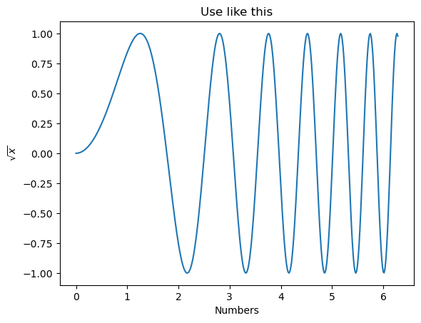

```python
fig, ax = plt.subplots()
ax.plot(x, y)
ax.set_title('Use like this')
ax.set_xlabel("Numbers");
#Whenever you use LaTeX in matplotlib: use r"$...$"
ax.set_ylabel(r"$\sqrt{x}$");
```

- Plot multiple lines into one canvas
- Call `ax.plot()` multiple times

```python
y2 = y/np.exp(y*1.5)
```

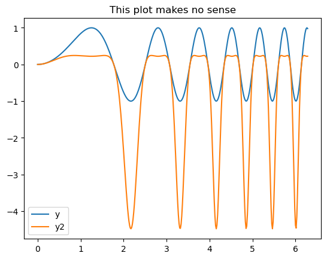

```python
fig, ax = plt.subplots()
ax.plot(x, y, label="y")
ax.plot(x, y2, label="y2")
ax.legend()
ax.set_title("This plot makes no sense");
```

- Matplotlib can also plot DataFrame data
- Because DataFrame data is *only* array-like data with stuff on top

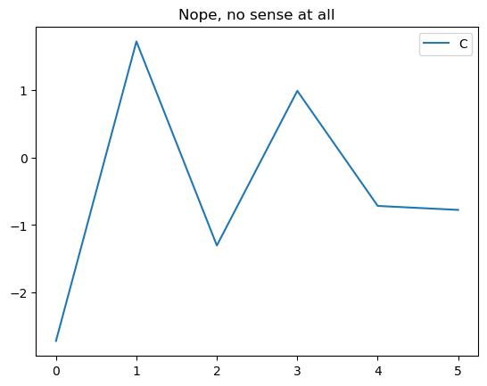

```python
fig, ax = plt.subplots()
ax.plot(df_demo.index, df_demo["C"], label="C")
ax.legend()
ax.set_title("Nope, no sense at all");
```

## Task 4

TASK

- Sort the Nest data frame by threads
- Plot `"Presim. Time / s"` and `"Sim. Time / s"` of our data frame `df` as a function of threads
- Use a dashed, red line for `"Presim. Time / s"`, a blue line for `"Sim. Time / s"` (see [API description](https://matplotlib.org/api/pyplot_api.html#matplotlib.pyplot.plot))
- Don't forget to label your axes and to add a legend *(1st rule of plotting)*
- Tell me when you're done with status icon in BigBlueButton: 👍

```python
df.sort_values(["Threads", "Nodes", "Tasks/Node", "Threads/Task"], inplace=True)  # multi-level sort
```

```python
df.columns
```

```
Index(['id', 'Nodes', 'Tasks/Node', 'Threads/Task', 'Runtime Program / s',
       'Scale', 'Plastic', 'Avg. Neuron Build Time / s',
       'Min. Edge Build Time / s', 'Max. Edge Build Time / s',
       'Min. Init. Time / s', 'Max. Init. Time / s', 'Presim. Time / s',
       'Sim. Time / s', 'Virt. Memory (Sum) / kB', 'Local Spike Counter (Sum)',
       'Average Rate (Sum)', 'Number of Neurons', 'Number of Connections',
       'Min. Delay', 'Max. Delay', 'Threads'],
      dtype='object')
```

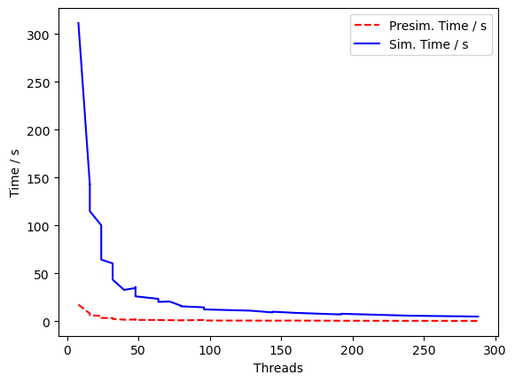

```python
fig, ax = plt.subplots()
ax.plot(df["Threads"], df["Presim. Time / s"], linestyle="dashed", color="red", label="Presim. Time / s")
ax.plot(df["Threads"], df["Sim. Time / s"], "-b", label="Sim. Time / s")
ax.set_xlabel("Threads")
ax.set_ylabel("Time / s")
ax.legend(loc='best');
```

## Plotting with Pandas

- Each data frame has a `.plot()` function (see [API](https://pandas.pydata.org/pandas-docs/stable/reference/api/pandas.DataFrame.plot.html))
- Plots with Matplotlib
- Important API options:
  - `kind`: `'line'` (default), `'bar[h]'`, `'hist'`, `'box'`, `'kde'`, `'scatter'`, `'hexbin'`
  - `subplots`: Make a sub-plot for each column (good together with `sharex`, `sharey`)
  - `figsize`
  - `grid`: Add a grid to plot (use Matplotlib options)
  - `style`: Line style per column (accepts list or dict)
  - `logx`, `logy`, `loglog`: Logarithmic plots
  - `xticks`, `yticks`: Use values for ticks
  - `xlim`, `ylim`: Limits of axes
  - `yerr`, `xerr`: Add uncertainty to data points
  - `stacked`: Stack a bar plot
  - `secondary_y`: Use a secondary `y` axis for this plot
  - Labeling
    - `title`: Add title to plot (Use a list of strings if `subplots=True`)
    - `legend`: Add a legend
    - `table`: If `true`, add table of data under plot
  - `**kwds`: Non-parsed keyword passed to Matplotlib's plotting methods
- Either slice and plot…

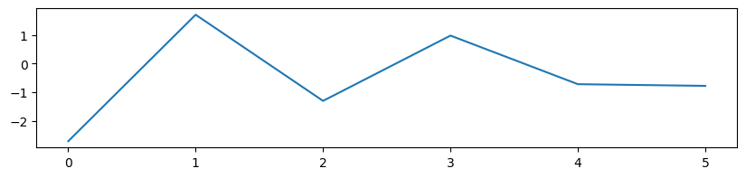

```python
df_demo["C"].plot(figsize=(10, 2));
```

- … or plot and select

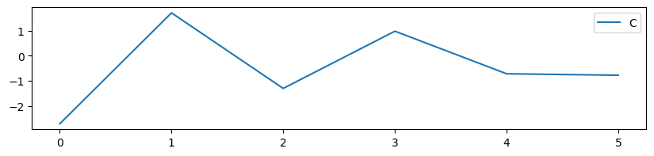

```python
df_demo.plot(y="C", figsize=(10, 2));
```

- I prefer slicing first:  
  → Allows for further operations on the sliced data frame

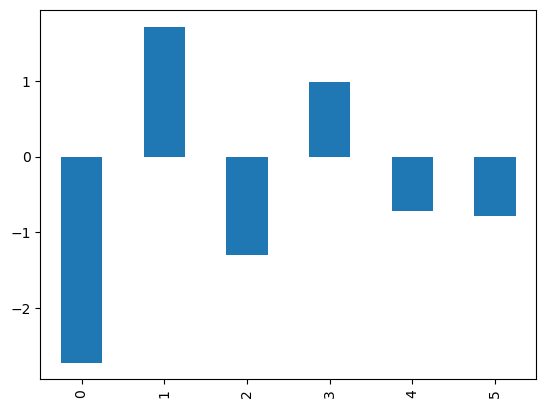

```python
df_demo["C"].plot(kind="bar");
```

- There are pseudo-sub-functions for each of the plot `kind`s
- I prefer to just call `.plot(kind="smthng")`

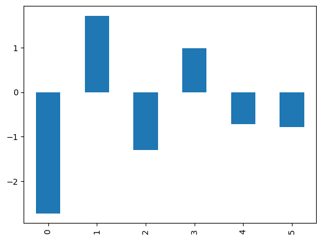

```python
df_demo["C"].plot.bar();
```

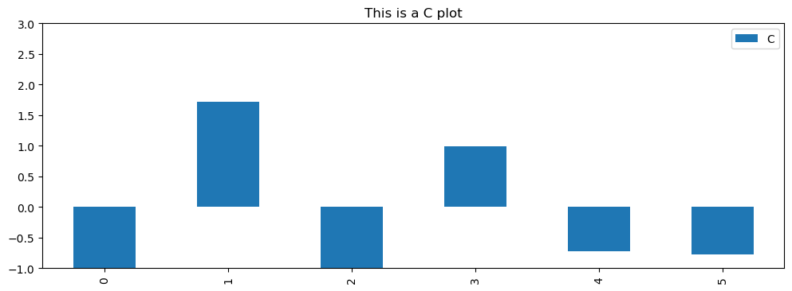

```python
df_demo["C"].plot(kind="bar", legend=True, figsize=(12, 4), ylim=(-1, 3), title="This is a C plot");
```

## Task 5

TASK

```python
df.set_index("Threads", inplace=True)
```

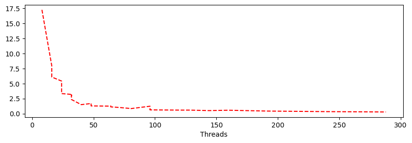

```python
df["Presim. Time / s"].plot(figsize=(10, 3), style="--", color="red");
```

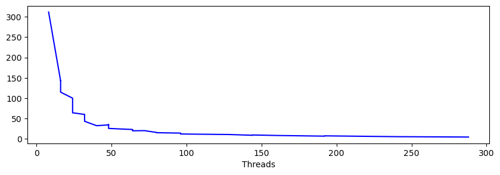

```python
df["Sim. Time / s"].plot(figsize=(10, 3), style="-b");
```

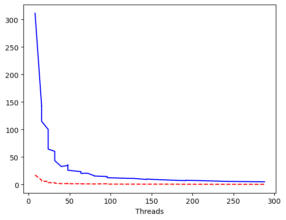

```python
df["Presim. Time / s"].plot(style="--r");
df["Sim. Time / s"].plot(style="-b");
```

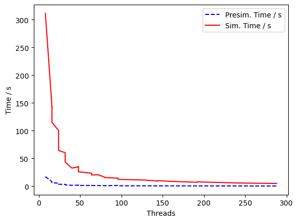

```python
ax = df[["Presim. Time / s", "Sim. Time / s"]].plot(style=["--b", "-r"]);
ax.set_ylabel("Time / s");
```

## More Plotting with Pandas

### Recap: Our first proper Pandas plot

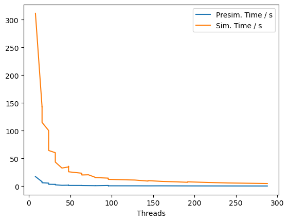

```python
df[["Presim. Time / s", "Sim. Time / s"]].plot();
```

- **That's why I think Pandas is great!**
- It has great defaults to quickly plot data; basically publication-grade already
- Plotting functionality is very versatile
- Before plotting, data can be *massaged* within data frames, if needed

## More Plotting with Pandas

### Some versatility

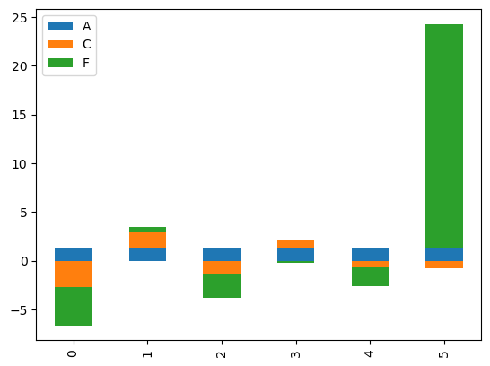

```python
df_demo[["A", "C", "F"]].plot(kind="bar", stacked=True);
```

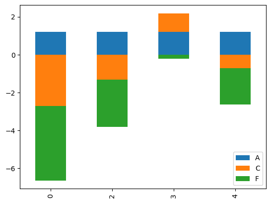

```python
df_demo[df_demo["F"] < 0][["A", "C", "F"]].plot(kind="bar", stacked=True);
```

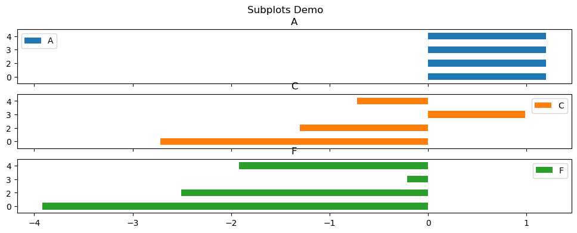

```python
df_demo[df_demo["F"] < 0][["A", "C", "F"]]\
    .plot(kind="barh", subplots=True, sharex=True, title="Subplots Demo", figsize=(12, 4));
```

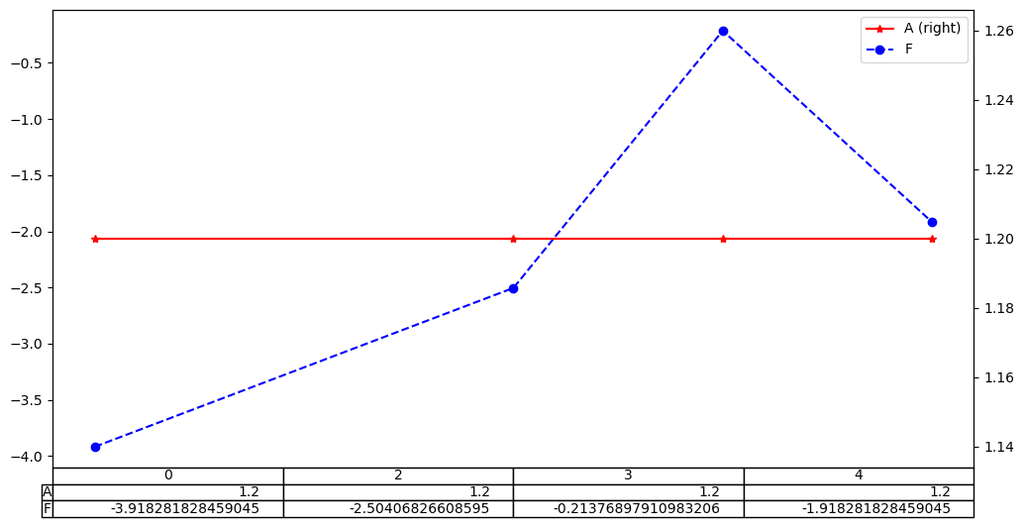

```python
df_demo.loc[df_demo["F"] < 0, ["A", "F"]]\
    .plot(
        style=["-*r", "--ob"],
        secondary_y="A",
        figsize=(12, 6),
        table=True
    );
```

```python
#df_demo.loc[df_demo["F"] < 0, ["A", "F"]]\
 #   .plot(
  #      style=["-*r", "--ob"],
   #     secondary_y="A",
    #    figsize=(12, 6),
     #   yerr={
      #      "A": df_demo[df_demo["F"] < 0]["C"],
       #     "F": 0.2
        #},
        #capsize=4,
        #title="Bug: style is ignored with yerr",
        #marker="P"
    #);
```

## Combine Pandas with Matplotlib

- Pandas shortcuts very handy
- But sometimes, one needs to access underlying Matplotlib functionality
- No problemo!
- **Option 1**: Pandas always returns axis
  - Use this to manipulate the canvas
  - Get underlying `figure` with `ax.get_figure()` (for `fig.savefig()`)
- **Option 2**: Create figure and axes with Matplotlib, use when drawing
  - `.plot()`: Use `ax` option

[output not shown]

### Option 1: Pandas Returns Axis

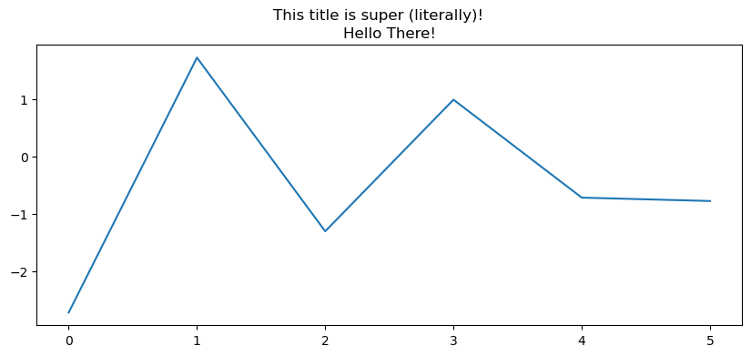

```python
ax = df_demo["C"].plot(figsize=(10, 4))
ax.set_title("Hello There!");
fig = ax.get_figure()
fig.suptitle("This title is super (literally)!");
```

### Option 2: Draw on Matplotlib Axes

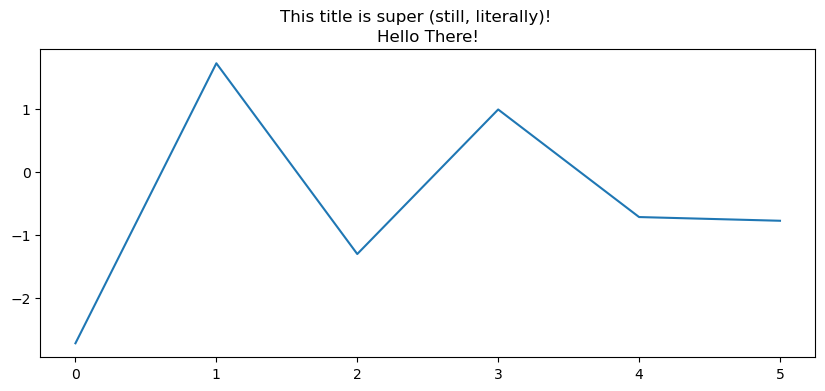

```python
fig, ax = plt.subplots(figsize=(10, 4))
df_demo["C"].plot(ax=ax)
ax.set_title("Hello There!");
fig.suptitle("This title is super (still, literally)!");
```

- We can also get fancy!

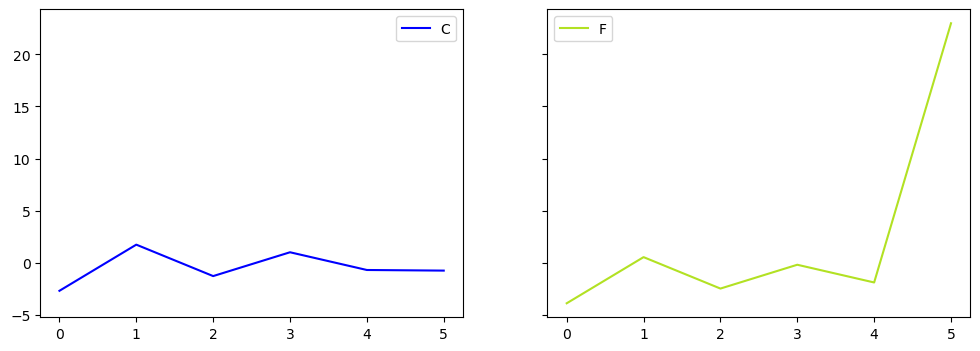

```python
fig, (ax1, ax2) = plt.subplots(ncols=2, sharey=True, figsize=(12, 4))
for ax, column, color in zip([ax1, ax2], ["C", "F"], ["blue", "#b2e123"]):
    df_demo[column].plot(ax=ax, legend=True, color=color)
```

## Aside: Seaborn

- Python package on top of Matplotlib
- Powerful API shortcuts for plotting of statistical data
- Manipulate color palettes
- Works well together with Pandas
- Also: New, well-looking defaults for Matplotlib (IMHO)
- → https://seaborn.pydata.org/

```python
import seaborn as sns
sns.set()  # set defaults
```

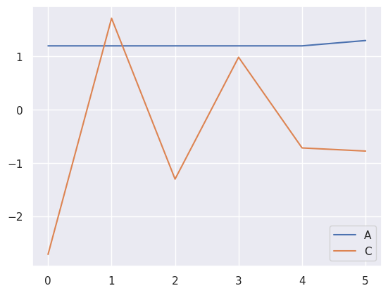

```python
df_demo[["A", "C"]].plot();
```

### Seaborn Color Palette Example

- [Documentation](https://seaborn.pydata.org/tutorial/color_palettes.html)

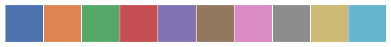

```python
sns.palplot(sns.color_palette())
```

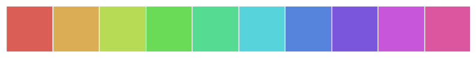

```python
sns.palplot(sns.color_palette("hls", 10))
```

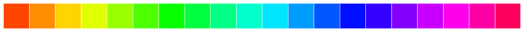

```python
sns.palplot(sns.color_palette("hsv", 20))
```

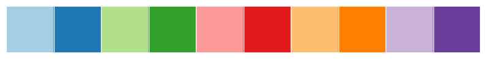

```python
sns.palplot(sns.color_palette("Paired", 10))
```

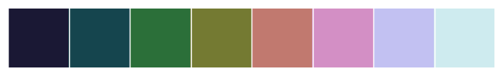

```python
sns.palplot(sns.color_palette("cubehelix", 8))
```

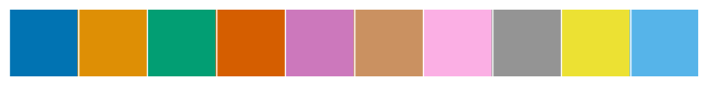

```python
sns.palplot(sns.color_palette("colorblind", 10))
```

### Seaborn Plot Examples

- Most of the time, I use a regression plot from Seaborn

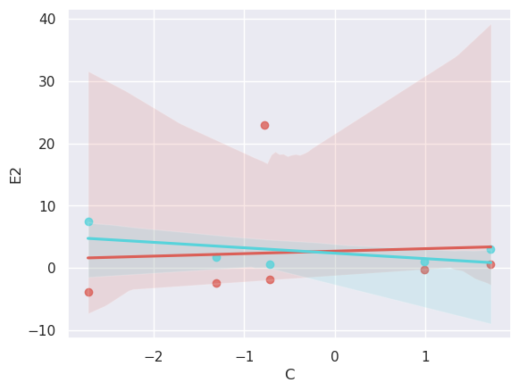

```python
with sns.color_palette("hls", 2):
    sns.regplot(x="C", y="F", data=df_demo);
    sns.regplot(x="C", y="E2", data=df_demo);
```

- A *joint plot* combines two plots relating to distribution of values into one
- Very handy for showing a fuller picture of two-dimensionally scattered variables

```python
x, y = np.random.multivariate_normal([0, 0], [[1, -.5], [-.5, 1]], size=300).T
```

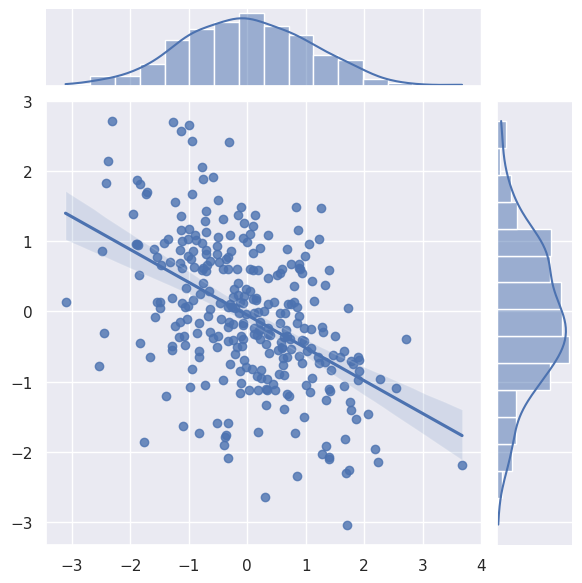

```python
sns.jointplot(x=x, y=y, kind="reg");
```

## Task 6

TASK

- To your `df` Nest data frame, add a column with the unaccounted time (`Unaccounted Time / s`), which is the difference of program runtime, average neuron build time, minimal edge build time, minimal initialization time, presimulation time, and simulation time.  
  (*I know this is technically not super correct, but it will do for our example.*)
- Plot a stacked bar plot of all these columns (except for program runtime) over the threads
- Tell me when you're done with status icon in BigBlueButton: 👍

```python
cols = [
    'Avg. Neuron Build Time / s',
    'Min. Edge Build Time / s',
    'Min. Init. Time / s',
    'Presim. Time / s',
    'Sim. Time / s'
]
df["Unaccounted Time / s"] = df['Runtime Program / s']
for entry in cols:
    df["Unaccounted Time / s"] = df["Unaccounted Time / s"] - df[entry]
```

```python
df[["Runtime Program / s", "Unaccounted Time / s", *cols]].head(2)
```

| Threads | Runtime Program / s | Unaccounted Time / s | Avg. Neuron Build Time / s | Min. Edge Build Time / s | Min. Init. Time / s | Presim. Time / s | Sim. Time / s |
| --- | --- | --- | --- | --- | --- | --- | --- |
| 8 | 420.42 | 2.09 | 0.29 | 88.12 | 1.14 | 17.26 | 311.52 |
| 16 | 202.15 | 2.43 | 0.28 | 47.98 | 0.70 | 7.95 | 142.81 |

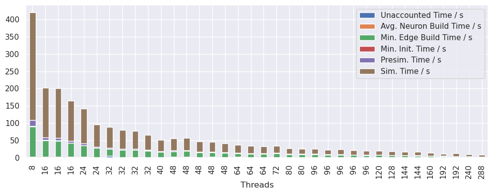

```python
df[["Unaccounted Time / s", *cols]].plot(kind="bar", stacked=True, figsize=(12, 4));
```

- Make it relative to the total program run time
- **Slight complication**: Our threads as indexes are not unique; we need to find new unique indexes
- Could be anythig, but we use a **multi index**!

```python
df_multind = df.set_index(["Nodes", "Tasks/Node", "Threads/Task"])
df_multind.head()
```

| Nodes | Tasks/Node | Threads/Task | id | Runtime Program / s | Scale | Plastic | Avg. Neuron Build Time / s | Min. Edge Build Time / s | Max. Edge Build Time / s | Min. Init. Time / s | Max. Init. Time / s | Presim. Time / s | Sim. Time / s | Virt. Memory (Sum) / kB | Local Spike Counter (Sum) | Average Rate (Sum) | Number of Neurons | Number of Connections | Min. Delay | Max. Delay | Unaccounted Time / s |
| --- | --- | --- | --- | --- | --- | --- | --- | --- | --- | --- | --- | --- | --- | --- | --- | --- | --- | --- | --- | --- | --- |
| 1 | 2 | 4 | 5 | 420.42 | 10 | True | 0.29 | 88.12 | 88.18 | 1.14 | 1.20 | 17.26 | 311.52 | 46560664.0 | 825499 | 7.48 | 112500 | 1265738500 | 1.5 | 1.5 | 2.09 |
|  |  | 8 | 5 | 202.15 | 10 | True | 0.28 | 47.98 | 48.48 | 0.70 | 1.20 | 7.95 | 142.81 | 47699384.0 | 802865 | 7.03 | 112500 | 1265738500 | 1.5 | 1.5 | 2.43 |
|  | 4 | 4 | 5 | 200.84 | 10 | True | 0.15 | 46.03 | 46.34 | 0.70 | 1.01 | 7.87 | 142.97 | 46903088.0 | 802865 | 7.03 | 112500 | 1265738500 | 1.5 | 1.5 | 3.12 |
| 2 | 2 | 4 | 5 | 164.16 | 10 | True | 0.20 | 40.03 | 41.09 | 0.52 | 1.58 | 6.08 | 114.88 | 46937216.0 | 802865 | 7.03 | 112500 | 1265738500 | 1.5 | 1.5 | 2.45 |
| 1 | 2 | 12 | 6 | 141.70 | 10 | True | 0.30 | 32.93 | 33.26 | 0.62 | 0.95 | 5.41 | 100.16 | 50148824.0 | 813743 | 7.27 | 112500 | 1265738500 | 1.5 | 1.5 | 2.28 |

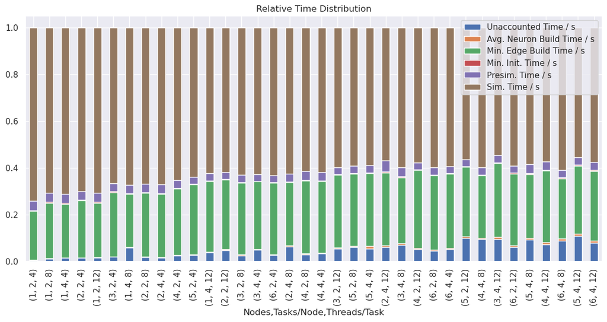

```python
df_multind[["Unaccounted Time / s", *cols]]\
    .divide(df_multind["Runtime Program / s"], axis="index")\
    .plot(kind="bar", stacked=True, figsize=(14, 6), title="Relative Time Distribution");
```